# Reproducible Research: Peer Assessment 1

```r
library(ggplot2)
```

## Loading and preprocessing the data

```r
if (!file.exists("activity.csv")) {
  unzip("activity.zip")
}

activity <- read.csv("activity.csv", stringsAsFactors = FALSE)

activity$date <- as.Date(activity$date, format = "%Y-%m-%d")
```

## What is mean total number of steps taken per day?

Calculate the total steps taken each day.

```r
totalStepsByDate <- aggregate(steps ~ date, data = activity, sum, na.action = na.omit)
```

Plot the histogram.

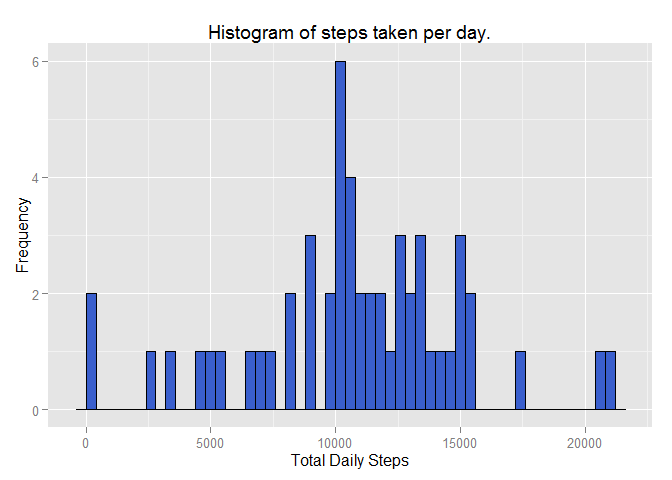

```r
print(
  qplot(
    x = steps,
    data = totalStepsByDate,
    geom = "histogram",
    color = I("black"),
    fill = I("royalblue3"),
    binwidth = 400,
    main = "Histogram of steps taken per day.",
    xlab = "Total Daily Steps",
    ylab = "Frequency"
  )
)
```

The mean of the total number of steps is:

```r
mean(totalStepsByDate$steps)
```

```
## [1] 10766.19
```

The median of the total number of steps is:

```r
median(totalStepsByDate$steps)
```

```
## [1] 10765
```

## What is the average daily activity pattern?

Calculate the mean steps for each interval.

```r
averageStepsByInterval <- aggregate(steps ~ interval, data = activity, mean, na.action = na.omit)
```

Plot the series.

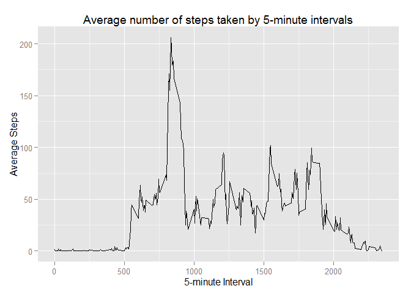

```r
print(
  qplot(
    interval,
    steps,
    data = averageStepsByInterval,
    geom = "line",
    main = "Average number of steps taken by 5-minute intervals",
    xlab = "5-minute Interval",
    ylab = "Average Steps"
  )
)
```

The 5-minute interval with the maximum steps on average is:

```r
averageStepsByInterval[averageStepsByInterval$steps == max(averageStepsByInterval$steps), ]
```

```
##     interval    steps
## 104      835 206.1698
```

## Imputing missing values

Total number of missing values:

```r
sum(is.na(activity$steps))
```

```
## [1] 2304
```

**Imputation Method**

Replace missing values with the mean for the 5-minute interval.

1. Merge original and average datasets
2. Replace NA values with mean value.

Step 1: Merge activity and averageStepsByInterval datasets

```r
activityImputed <- merge(activity, averageStepsByInterval, by.x = "interval", by.y = "interval")
names(activityImputed) <- c("interval", "steps", "date", "meanStepsByInterval")
```

Step2: Replace NA values with mean value.

```r
activityImputed$steps[is.na(activityImputed$steps)] <- activityImputed[is.na(activityImputed$steps), "meanStepsByInterval"]
```

As before, show histogram, mean and median, this time with imputed data.

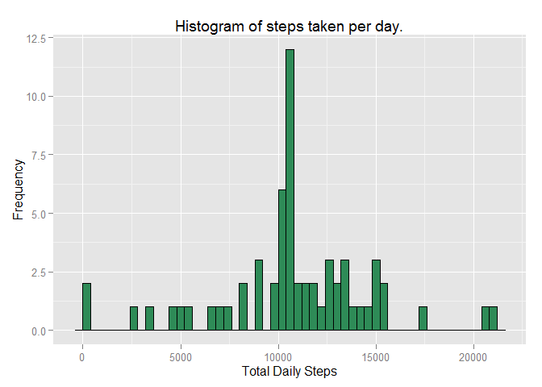

```r
totalStepsByDateImputed <- aggregate(steps ~ date, data = activityImputed, sum)

print(
  qplot(
    x = steps,
    data = totalStepsByDateImputed,
    geom = "histogram",
    color = I("black"),
    fill = I("seagreen4"),
    binwidth = 400,
    main = "Histogram of steps taken per day.",
    xlab = "Total Daily Steps",
    ylab = "Frequency"
  )
)
```

The mean of the total number of steps is:

```r
mean(totalStepsByDateImputed$steps)
```

```
## [1] 10766.19
```

The median of the total number of steps is:

```r
median(totalStepsByDateImputed$steps)
```

```
## [1] 10766.19
```

## Are there differences in activity patterns between weekdays and weekends?

Add daytype factor column indicating if the date is a weekday or weekend.

```r
activityImputed$daytype <- factor(ifelse(weekdays(activityImputed$date) %in% c("Saturday", "Sunday"), "weekend", "weekday"))
```

Take the average steps by interval and day type.

```r
averageStepsByIntervalAndDayType <- aggregate(steps ~ interval + daytype, data = activityImputed, mean)
```

Plot the two day type series.

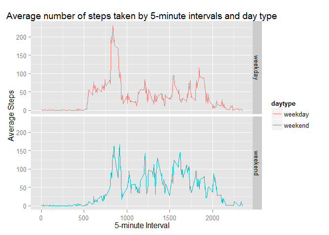

```r
print(
  qplot(
    interval,
    steps,
    data = averageStepsByIntervalAndDayType,
    color = daytype,
    facets = daytype ~ .,
    geom = "line",
    main = "Average number of steps taken by 5-minute intervals and day type",
    xlab = "5-minute Interval",
    ylab = "Average Steps"
  )
)
```